# Multiomocs data analysis on lung cancer by MOFA

sara yusuf

2024-03-01

# library laoading

first of all we need to install the requiered packages …

```r
library(BiocManager)
library(basilisk)
```

```r
library(basilisk)
library(magrittr)
library(ggplot2)
library(ggrepel)
library(tidyverse)
library(vegan)
library(devtools)
library(data.table)
library(MOFA2)
library(readr)
```

# data loading

reading the rna, protein and methylation matrices that were already processed plus the metadata matrix.

```r
rna = read.csv("rna" ,row.names = 1, header = T )
meth = read.csv("meth",row.names = 1, header = T )
prot = read.csv("prot",row.names = 1, header = T )
meta = read.csv("meta",row.names = 1, header = T )
```

# data wrangling

now some exploration and matching to unify the common samples between omics data

```r
dim(rna)
```

```
## [1] 12688   211
```

```r
dim(meth)
```

```
## [1] 16478   194
```

```r
dim(prot)
```

```
## [1] 10695   207
```

```r
rna = as.matrix(rna)
meth = as.matrix(meth)
prot = as.matrix(prot)
```

```r
i_col = intersect(colnames(meth), colnames(rna))
```

```r
rna  = rna [ , i_col]
meth = meth[ , i_col]
prot = prot[ , i_col]
meta = meta[i_col , ]
```

```r
dim(rna)
```

```
## [1] 12688   194
```

```r
dim(meth)
```

```
## [1] 16478   194
```

```r
dim(prot)
```

```
## [1] 10695   194
```

```r
all(colnames(rna) == colnames(meth))
```

```
## [1] TRUE
```

```r
all(colnames(rna) == colnames(prot))
```

```
## [1] TRUE
```

we need to compile all data into a list of matrices

```r
data = list(rna = rna , meth = meth , prot = prot)
```

```r
lapply(data,dim)
```

```
## $rna
## [1] 12688   194
##
## $meth
## [1] 16478   194
##
## $prot
## [1] 10695   194
```

# Fitting the model

moving to preparing the MOFA object to fit the model

```r
MOFAobject = create_mofa(data)
```

```
## Creating MOFA object from a list of matrices (features as rows, sample as columns)...
```

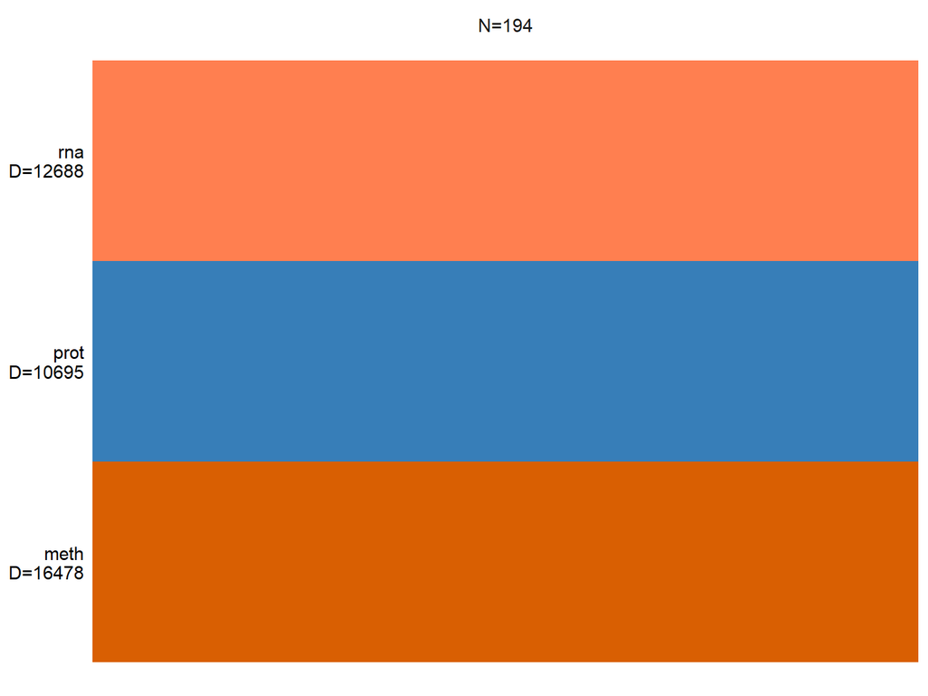

```r
plot_data_overview(MOFAobject)
```

```r
data_opts = get_default_data_options(MOFAobject)
data_opts
```

```
## $scale_views
## [1] FALSE
##
## $scale_groups
## [1] FALSE
##
## $center_groups
## [1] TRUE
##
## $use_float32
## [1] TRUE
##
## $views
## [1] "rna"  "meth" "prot"
##
## $groups
## [1] "group1"
```

```r
model_opts = get_default_model_options(MOFAobject)
model_opts$num_factors = 10

model_opts
```

```
## $likelihoods
##        rna       meth       prot
## "gaussian" "gaussian" "gaussian"
##
## $num_factors
## [1] 10
##
## $spikeslab_factors
## [1] FALSE
##
## $spikeslab_weights
## [1] FALSE
##
## $ard_factors
## [1] FALSE
##
## $ard_weights
## [1] TRUE
```

```r
train_opts = get_default_training_options(MOFAobject )
train_opts$convergence_mode = "slow"

train_opts
```

```
## $maxiter
## [1] 1000
##
## $convergence_mode
## [1] "slow"
##
## $drop_factor_threshold
## [1] -1
##
## $verbose
## [1] FALSE
##
## $startELBO
## [1] 1
##
## $freqELBO
## [1] 5
##
## $stochastic
## [1] FALSE
##
## $gpu_mode
## [1] FALSE
##
## $gpu_device
## NULL
##
## $seed
## [1] 42
##
## $outfile
## NULL
##
## $weight_views
## [1] FALSE
##
## $save_interrupted
## [1] FALSE
```

```r
MOFAobject = prepare_mofa(
  object = MOFAobject,
  data_options = data_opts,
  model_options = model_opts,
  training_options = train_opts
)
```

```
## Checking data options...
```

```
## Checking training options...
```

```
## Checking model options...
```

```r
#outfile = file.path(getwd(),"model.hdf5")
#MOFAobject.trained = run_mofa(MOFAobject, outfile)
```

```r
MOFAobject.trained = load_model("model.hdf5")
```

after fitting the model … some exploration and visualization

```r
names(MOFAobject.trained@data)
```

```
## [1] "rna"  "meth" "prot"
```

```r
dim(MOFAobject.trained@data$rna$group1)
```

```
## [1] 12688   194
```

```r
names(MOFAobject.trained@expectations)
```

```
## [1] "Z" "W"
```

```r
dim(MOFAobject.trained@expectations$W$rna)
```

```
## [1] 12688    10
```

we need to familiarize our model with the metadata in order to start comparison

```r
meta = meta%>%
  rownames_to_column("sample")
```

```r
 stopifnot(all(sort(meta$sample) == sort(unlist(samples_names(MOFAobject.trained)))))
```

```r
samples_metadata(MOFAobject.trained) = meta
```

```r
head(MOFAobject.trained@cache$variance_explained$r2_total[[1]]) # group 1
```

```
##      rna     meth     prot
## 99.82605 54.45543 37.05223
```

```r
head(MOFAobject.trained@cache$variance_explained$r2_per_factor[[1]]) # group 1
```

```
##                   rna        meth         prot
## Factor1  9.977991e+01  4.92684841 25.189220905
## Factor2 -2.727389e-01 33.73036981  0.010991096
## Factor3 -1.192093e-05  0.03212690  8.881896734
## Factor4  1.192093e-05  4.85546589  0.003200769
## Factor5  4.172325e-05  3.85293961  0.501859188
## Factor6  4.172325e-05  0.03433824  4.207068682
```

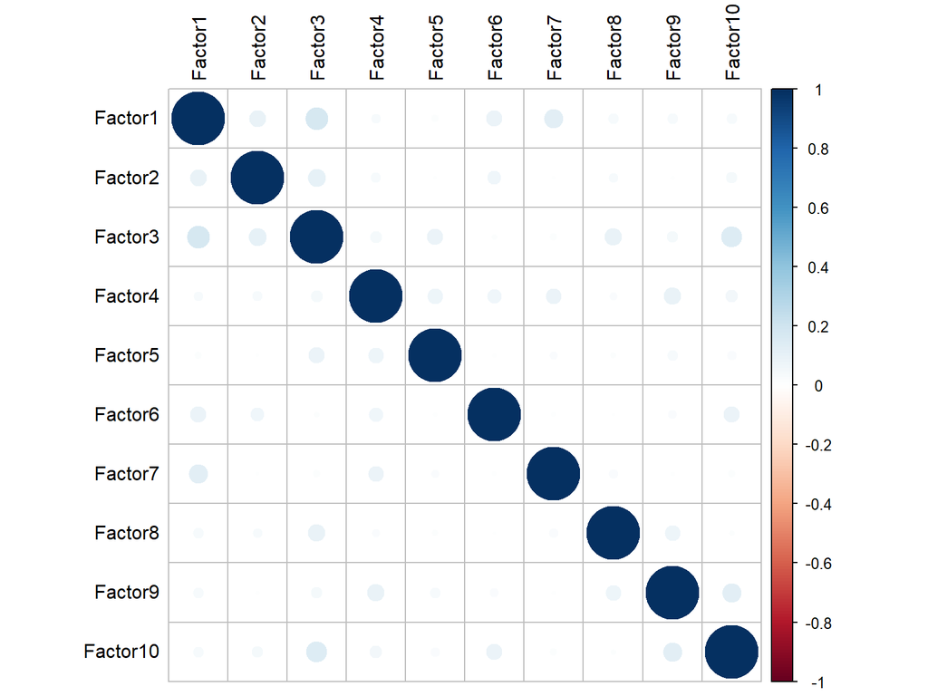

```r
plot_factor_cor(MOFAobject.trained)
```

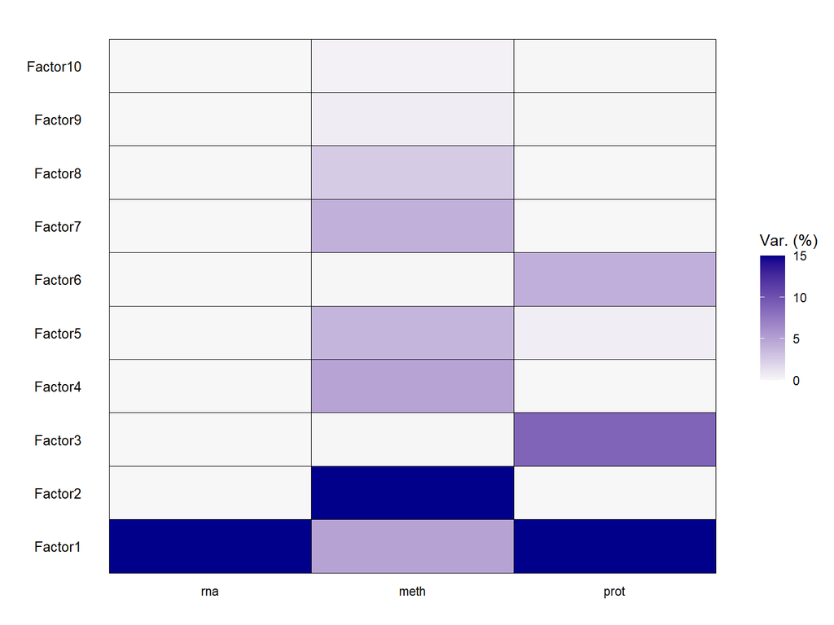

```r
plot_variance_explained(MOFAobject.trained, max_r2=15)
```

this is the the total variance between our omics , we can tell that “factor 1” explains the most of variation and the rna data is the one that differentiate my samples the most..

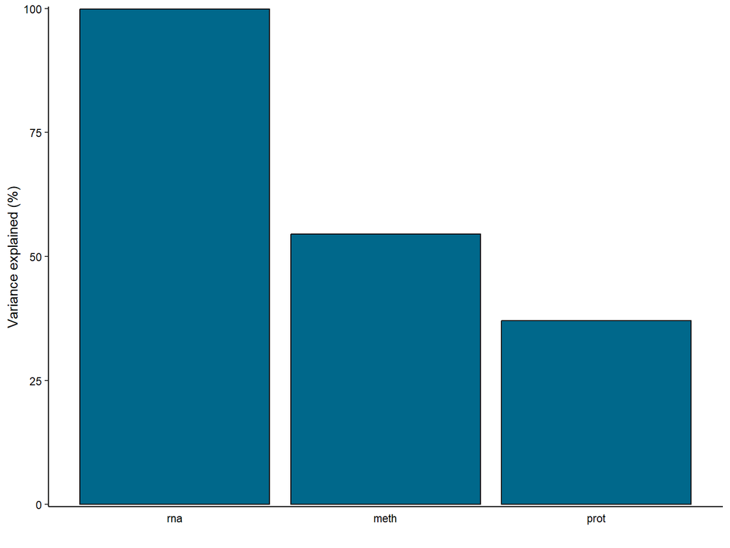

```r
plot_variance_explained(MOFAobject.trained, plot_total = T)[[2]]
```

here again another proof the the RNA data explaine the most variation among the samples

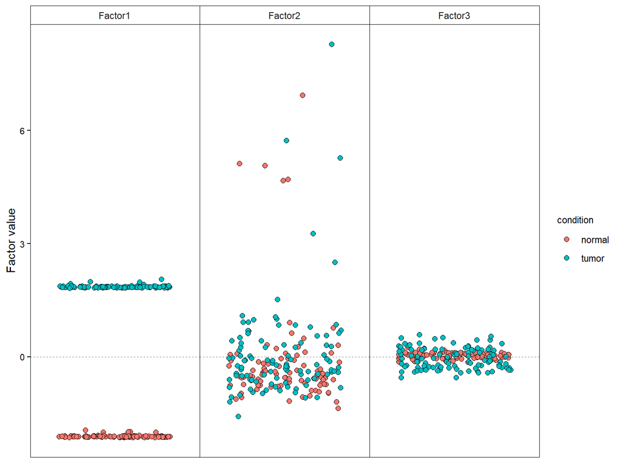

```r
plot_factor(MOFAobject.trained,
  factor = 1:3,
  color_by = "condition",
)
```

this graph is to capture the influence of the condition among samples from the first three factors point of wiew , as we can see it is obvious that factor1 can clearly separate samples into two distinct groups by condition (NORMAL VS TUMOR). by looking at factor 2 and 3 it becomes less distinct.

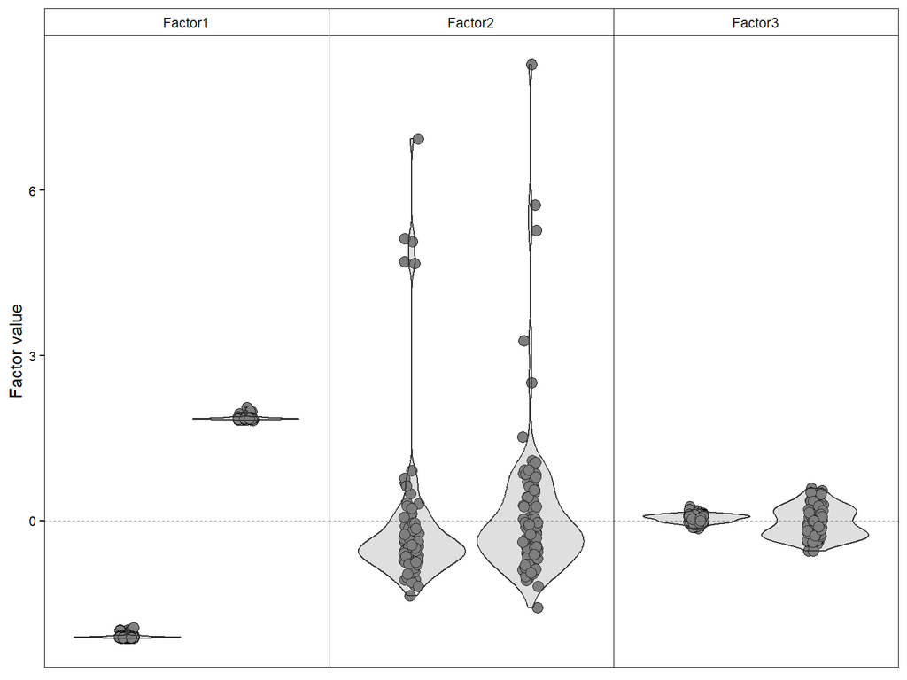

```r
p = plot_factor(MOFAobject.trained,
  factors = c(1,2,3),
  color_by = "condition",
  dot_size = 3,
  dodge = T,
  legend = F,
  add_violin = T,
  violin_alpha = 0.25
)

p = p +
  scale_color_manual(values=c("A"="black", "B"="red")) +
  scale_fill_manual(values=c("A"="black", "B"="red"))

print(p)
```

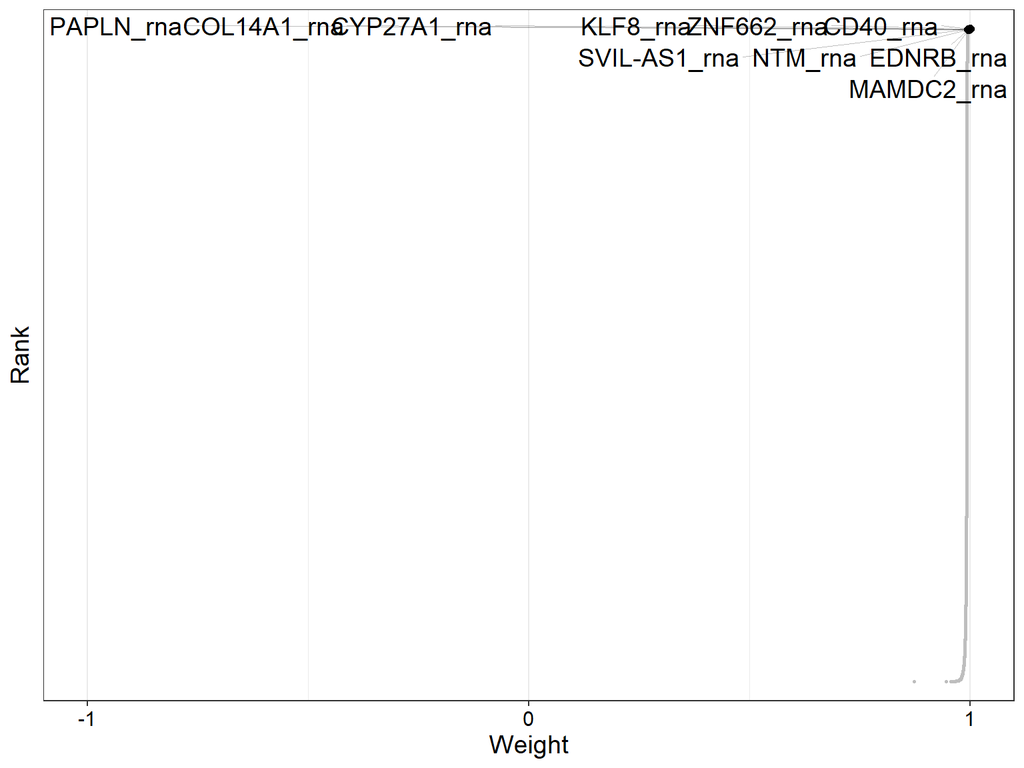

```r
plot_weights(MOFAobject.trained,
 view = "rna",
 factor = 1,
 nfeatures = 10,     # Top number of features to highlight
 scale = T           # Scale weights from -1 to 1
)
```

the graph aims to plot RNA features that have to heaviest weights to influence variance , all those genes are considered the most important of all. the same is applied to the rest of omics data and some features stood out.

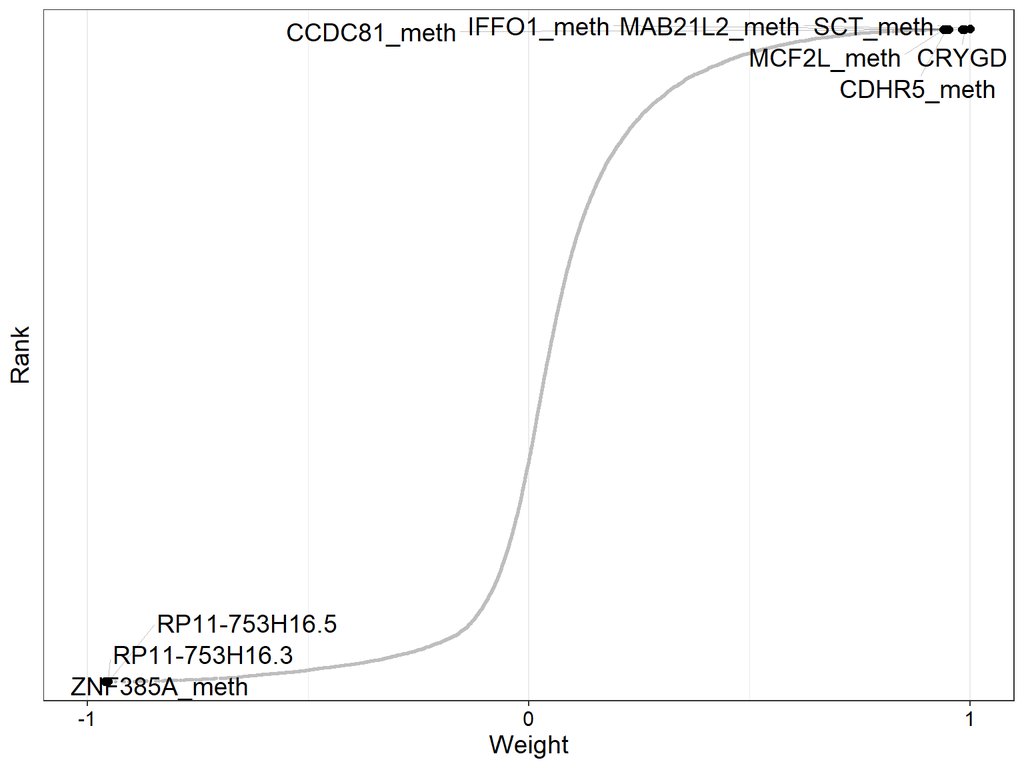

```r
plot_weights(MOFAobject.trained,
 view = "meth",
 factor = 1,
 nfeatures = 10,     # Top number of features to highlight
 scale = T           # Scale weights from -1 to 1
)
```

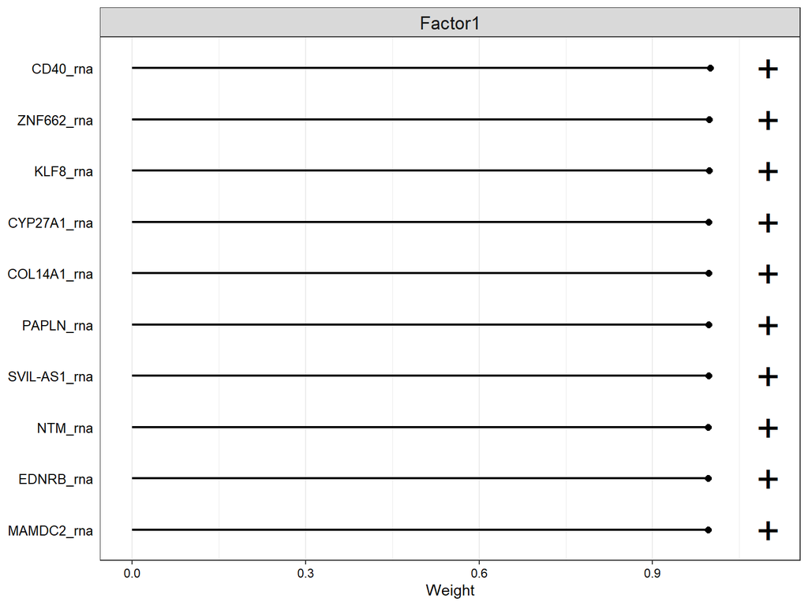

```r
plot_top_weights(MOFAobject.trained,
 view = "rna",
 factor = 1,
 nfeatures = 10,     # Top number of features to highlight
 scale = T
 )
```

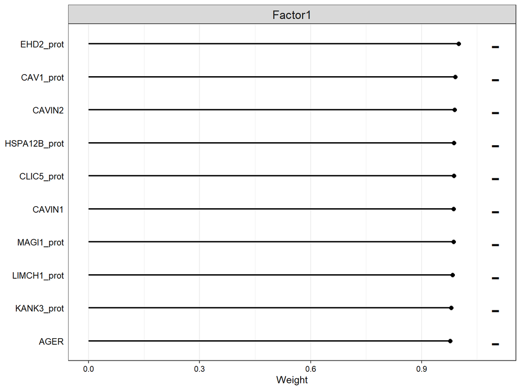

```r
plot_top_weights(MOFAobject.trained,
 view = "prot",
 factor = 1,
 nfeatures = 10,     # Top number of features to highlight
 scale = T           # Scale weights from -1 to 1
)
```

we took as example (NTM) and (CD40) , one of the genes that showed a high wt on varianation , we specified the search to be only on factor 1 since it explains variancse the most , and a clear cut line appeared between samples to emphasize again that these feature’s role cannot be ignored in the process of lung cancer incidence

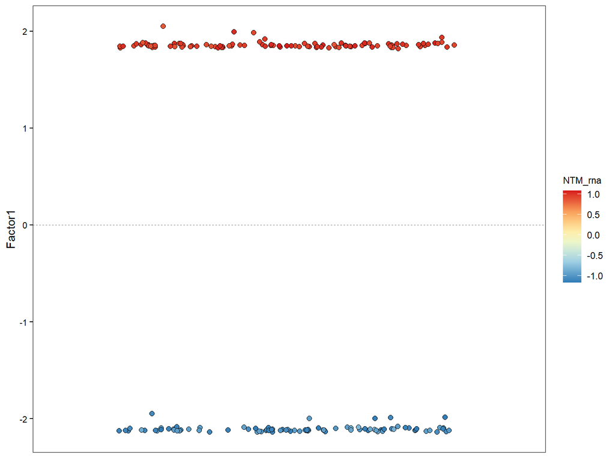

```r
plot_factor(MOFAobject.trained,
  factors = 1,
  color_by = "NTM_rna",
  dodge = TRUE,
  add_violin = TRUE)
```

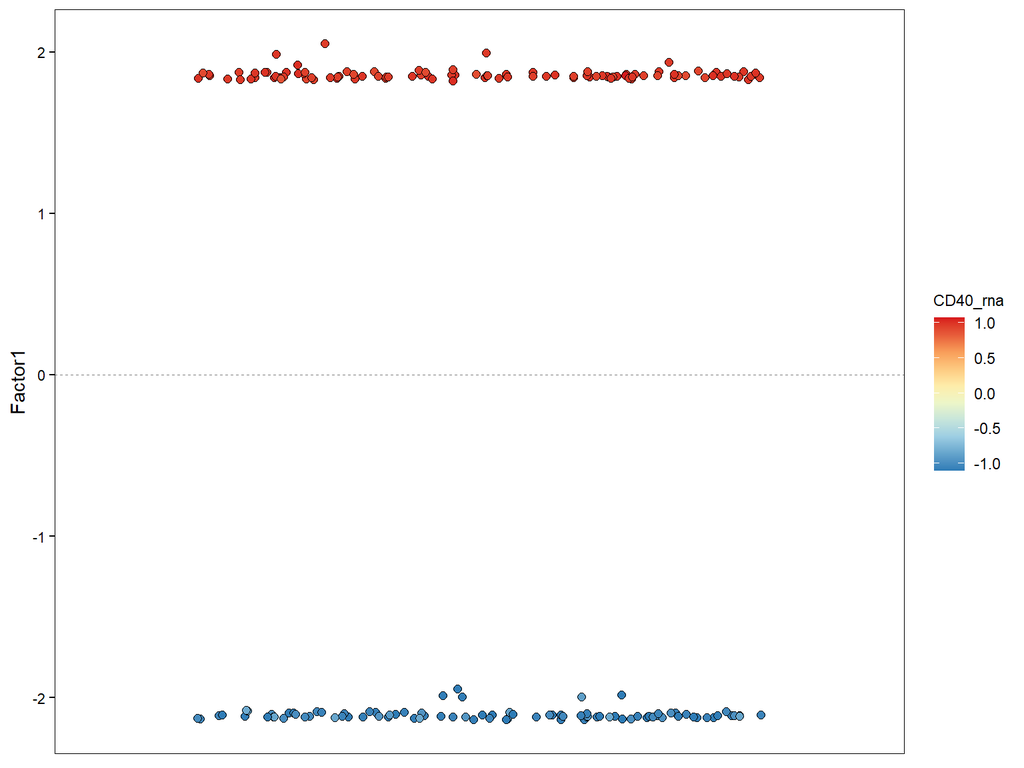

```r
plot_factor(MOFAobject.trained,
  factors = 1,
  color_by = "CD40_rna",
  dodge = TRUE,
  add_violin = TRUE)
```

upon plotting the gender influence on the tumor formation , it had no clear association . the tumor was almost equally happening to both genders.

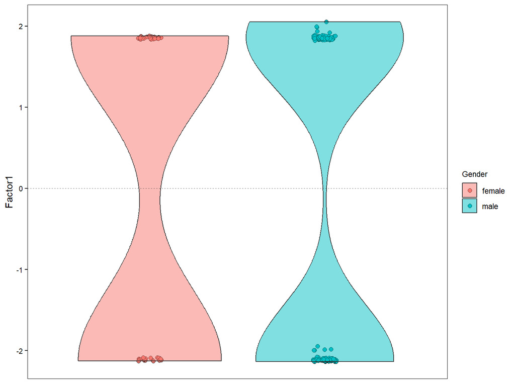

```r
plot_factor(MOFAobject.trained,
  factors = 1,
  color_by = "Gender",
  dodge = TRUE,
  add_violin = TRUE
)
```

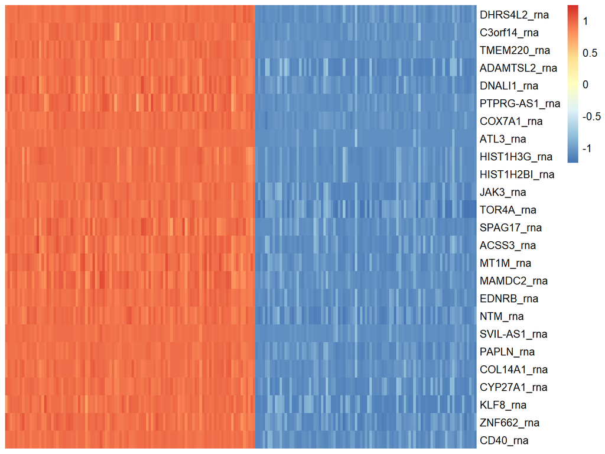

```r
plot_data_heatmap(MOFAobject.trained,
  view = "rna",
  factor = 1,
  features = 25,
  cluster_rows = FALSE, cluster_cols = FALSE,
  show_rownames = TRUE, show_colnames = FALSE,
  scale = "row"
)
```

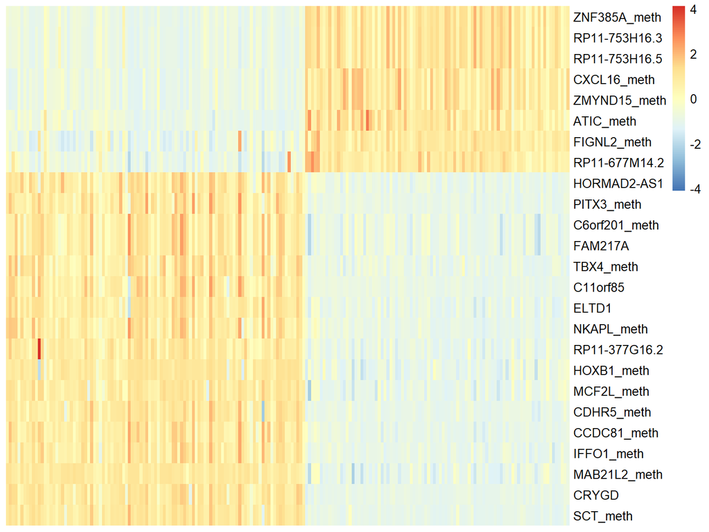

```r
plot_data_heatmap(MOFAobject.trained,
  view = "meth",
  factor = 1,
  features = 25,
  cluster_rows = FALSE, cluster_cols = FALSE,
  show_rownames = TRUE, show_colnames = FALSE,
  scale = "row")
```

now we zoomed on factor 1 and drew a heatmap to defferentiate the samples deppending on both RNA and methylation data. we can conclude that there is a contrast among features. some are highly up regulated and others down regulated

```r
#if (!require("BiocManager", quietly = TRUE))
 #   install.packages("BiocManager")

#BiocManager::install("MOFAdata")
```

# Enrichment analysis

let’s perform an enrichment analysis to figure out which pathways are more involved in lung cancer

```r
library(MOFAdata)
library(data.table)
library(cowplot)
```

we will do some processing to modify feature names in order to match them with the database

```r
features_names(MOFAobject.trained)[["rna"]] = toupper(features_names(MOFAobject.trained)[["rna"]])

features_names(MOFAobject.trained)[["rna"]] = sub("_.*", "", features_names(MOFAobject.trained)[["rna"]] )

head(features_names(MOFAobject.trained)[["rna"]])
```

```
## [1] "A1BG"     "A1BG-AS1" "A4GALT"   "AAAS"     "AACS"     "AADAT"
```

biomart is good package to mach ensamble gene ID with the gene name because the database only can identify the gene ID , however our features are gene names

```r
library('biomaRt')

mart = useMart('ENSEMBL_MART_ENSEMBL')
mart = useDataset('hsapiens_gene_ensembl', mart)

annotLookup = getBM(
  mart = mart,
  attributes = c(
    'hgnc_symbol',
    'ensembl_gene_id',
    'gene_biotype'),
  uniqueRows = TRUE)

head(annotLookup)
```

```
##   hgnc_symbol ensembl_gene_id   gene_biotype
## 1       MT-TF ENSG00000210049        Mt_tRNA
## 2     MT-RNR1 ENSG00000211459        Mt_rRNA
## 3       MT-TV ENSG00000210077        Mt_tRNA
## 4     MT-RNR2 ENSG00000210082        Mt_rRNA
## 5      MT-TL1 ENSG00000209082        Mt_tRNA
## 6      MT-ND1 ENSG00000198888 protein_coding
```

```r
length(annotLookup$hgnc_symbol)
```

```
## [1] 70712
```

```r
idx = match(features_names(MOFAobject.trained)[["rna"]] ,annotLookup$hgnc_symbol)
```

```r
matched = features_names(MOFAobject.trained)[["rna"]][idx]
```

```r
matched = na.omit(matched)
```

```r
length(matched)
```

```
## [1] 1680
```

```r
length(features_names(MOFAobject.trained)[["rna"]])
```

```
## [1] 12688
```

```r
df = data.frame(hgnc_symbol= matched)
```

```r
my.genes = inner_join(annotLookup , df , by ="hgnc_symbol" )
```

```r
data("reactomeGS")
```

```r
head(rownames(reactomeGS), n=3)
```

```
## [1] "Interleukin-6 signaling" "Apoptosis"
## [3] "Hemostasis"
```

```r
head(colnames(reactomeGS), n=3)
```

```
## [1] "ENSG00000187634" "ENSG00000188976" "ENSG00000187961"
```

```r
db = t(reactomeGS)
```

```r
db = db%>%
  data.frame%>%
  rownames_to_column("ensembl_gene_id")
```

```r
db = inner_join(db , my.genes , by = "ensembl_gene_id")
```

```r
db.sorted = db[ , c("hgnc_symbol",
                        names(db)[names(db) != "hgnc_symbol"])]
```

```r
db = db.sorted%>%
  dplyr::select(-ensembl_gene_id)
```

```r
db = setNames(data.frame(t(db[,-1])), db[,1])
```

```r
db = as.matrix((db > 0) + 0)
```

it’s time to enrich… firt the up regualted .. then the down regulated features of RNA

```r
# GSEA on positive weights, with default options

res.positive = run_enrichment(MOFAobject.trained,
  feature.sets = db,
  view = "rna",
  sign = "positive"
)
```

```
## Intersecting features names in the model and the gene set annotation results in a total of 1512 features.
```

```
##
## Running feature set Enrichment Analysis with the following options...
## View: rna
## Number of feature sets: 298
## Set statistic: mean.diff
## Statistical test: parametric
```

```
## Subsetting weights with positive sign
```

```r
# GSEA on negative weights, with default options
res.negative = run_enrichment(MOFAobject.trained,
  feature.sets = db,
  view = "rna",
  sign = "negative"
)
```

```
## Intersecting features names in the model and the gene set annotation results in a total of 1512 features.
```

```
##
## Running feature set Enrichment Analysis with the following options...
## View: rna
## Number of feature sets: 298
## Set statistic: mean.diff
## Statistical test: parametric
```

```
## Subsetting weights with negative sign
```

```r
names(res.positive)
```

```
## [1] "feature.sets"       "pval"               "pval.adj"
## [4] "feature.statistics" "set.statistics"     "sigPathways"
```

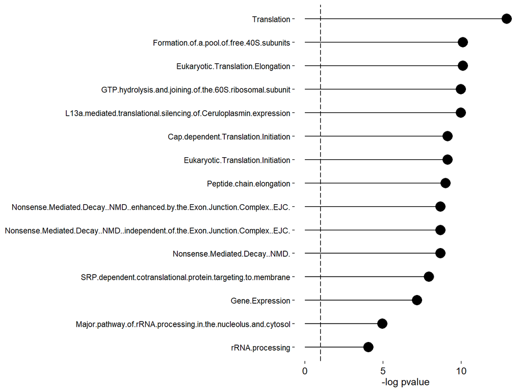

```r
plot_enrichment(res.positive, factor = 5, max.pathways = 15)
```

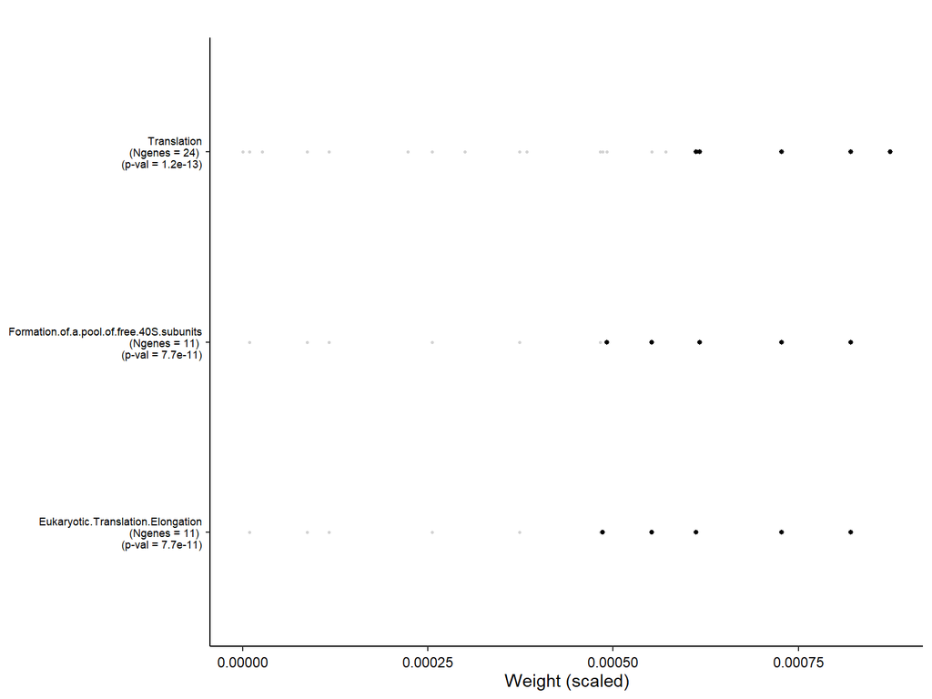

```r
plot_enrichment_detailed(
  enrichment.results = res.positive,
  factor = 5,
  max.pathways = 3
)
```

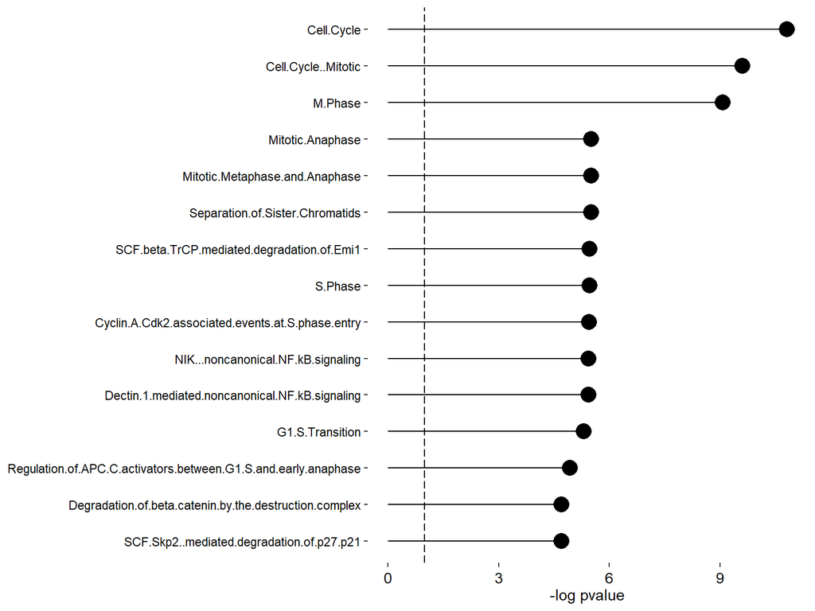

```r
plot_enrichment(res.negative, factor = 5, max.pathways = 15)
```

```r
features_names(MOFAobject.trained)[["prot"]] = toupper(features_names(MOFAobject.trained)[["prot"]])

features_names(MOFAobject.trained)[["prot"]] = sub("_.*", "", features_names(MOFAobject.trained)[["prot"]] )

head(features_names(MOFAobject.trained)[["prot"]])
```

```
## [1] "A1BG"   "A2M"    "A2ML1"  "A4GALT" "AAAS"   "AACS"
```

```r
# GSEA on positive weights, with default options

res.positive.prot = run_enrichment(MOFAobject.trained,
  feature.sets = db,
  view = "prot",
  sign = "positive"
)
```

```
## Intersecting features names in the model and the gene set annotation results in a total of 1068 features.
```

```
##
## Running feature set Enrichment Analysis with the following options...
## View: prot
## Number of feature sets: 228
## Set statistic: mean.diff
## Statistical test: parametric
```

```
## Subsetting weights with positive sign
```

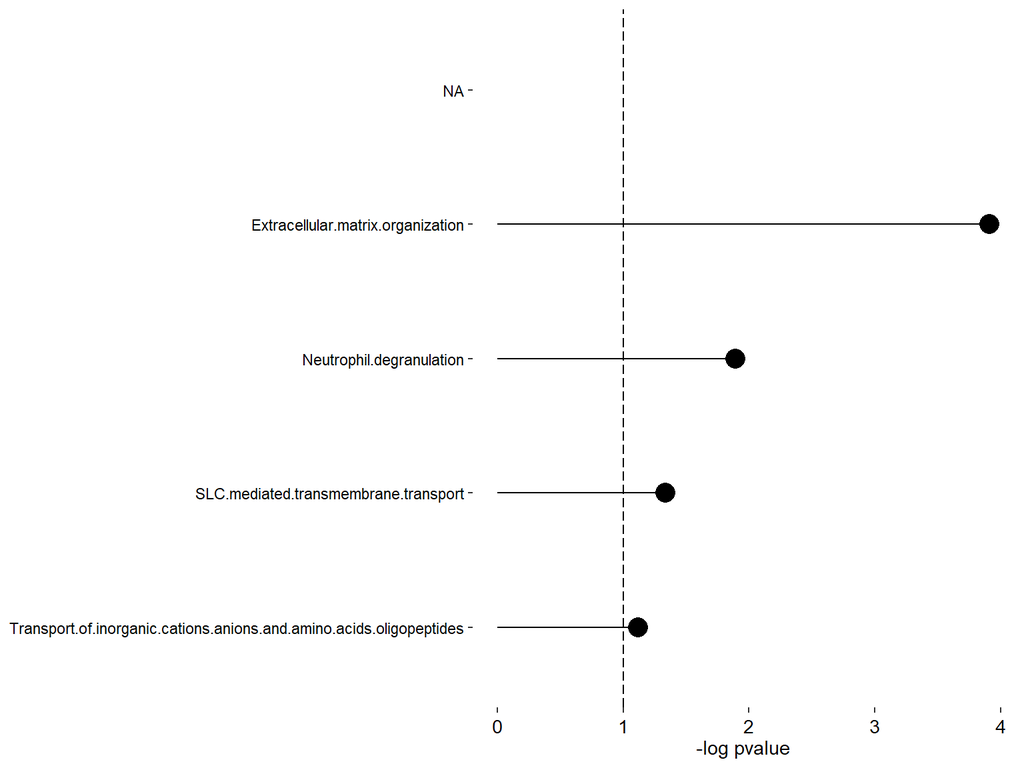

```r
plot_enrichment(res.positive.prot, factor = 5, max.pathways = 15)
```

```r
res.all = run_enrichment(
  MOFAobject.trained,
  view = c("rna" , "meth" ,"prot"),
  feature.sets = db,
  factors = "all",
  set.statistic = c("mean.diff", "rank.sum"),
  statistical.test = c("parametric", "cor.adj.parametric", "permutation"),
  sign = c("all", "positive", "negative"),
  min.size = 10,
  nperm = 1000,
  p.adj.method = "BH",
  alpha = 0.1,
  verbose = TRUE
)
```

```
## Intersecting features names in the model and the gene set annotation results in a total of 1512 features.
```

```
##
## Running feature set Enrichment Analysis with the following options...
## View: rna
## View: meth
## View: prot
## Number of feature sets: 298
## Set statistic: mean.diff
## Statistical test: parametric
```

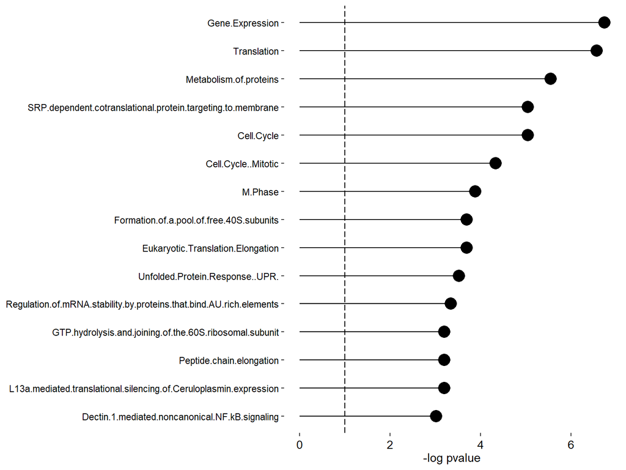

```r
plot_enrichment(res.all, factor = 5, max.pathways = 15)
```